← saditahmid.github.io Mohammed Tahmid Hossain

Data Cleaning · EDA · SVR Forecasting · IEEE INCET 2023

# Air Quality in Bangladesh: Cleaning, Exploration & COVID-19 Forecasting

End-to-end analysis of AQI readings across 10 Bangladeshi cities — from raw data cleaning and exploratory analysis through to Support Vector Regression forecasting of the COVID-19 lockdown's impact on air quality. Companion to IEEE INCET 2023.

PythonPandasData CleaningEDASVRForecasting

EXPLORATORY DATA ANALYSIS

# Air Quality Index Analysis in Bangladesh

A longitudinal study of pollution trends across 13 cities from 2014–2022, examining seasonal patterns, urban disparities, and the environmental impact of COVID-19 lockdowns.

📍 13 Cities 📅 2014 – 2022 📊 ~21,000 Records 🐍 Python · Pandas · Seaborn

## 📌 Background & Context

Bangladesh is consistently ranked among the most air-polluted countries in the world. Rapid urbanization, industrial growth, brick kilns, and vehicle emissions have made cities like Dhaka and Rangpur hotspots for particulate matter.

The **Air Quality Index (AQI)** is a standardized scale that communicates how polluted the air is and what health effects may be of concern. It is calculated from key pollutants including PM2.5, PM10, NO₂, SO₂, CO, and O₃.

| AQI Range | Category | Health Implication |
| --- | --- | --- |
| 0 – 50 | 🟢 Good | Air quality is satisfactory |
| 51 – 100 | 🟡 Moderate | Acceptable; some pollutants may concern sensitive people |
| 101 – 150 | 🟠 Unhealthy for Sensitive Groups | Sensitive groups may experience effects |
| 151 – 200 | 🔴 Unhealthy | Everyone may begin to experience effects |
| 201 – 300 | 🟣 Very Unhealthy | Health alert: serious effects for everyone |
| 301+ | 🟤 Hazardous | Emergency conditions; entire population affected |

> **Dataset Source:** Department of Environment (DoE), Bangladesh — daily AQI readings across major cities, collected via government monitoring stations.

## 📋 Table of Contents

1. Setup & Configuration
2. Data Loading & First Look
3. Data Quality Assessment
4. Data Cleaning
5. Exploratory Data Analysis
   - 5.1 Overview Statistics
   - 5.2 AQI Category Distribution
   - 5.3 City Rankings
   - 5.4 Seasonal Patterns
   - 5.5 Year-over-Year Trends
   - 5.6 Time Series & COVID-19 Context
   - 5.7 Proportion of Unhealthy Air Days
   - 5.8 AQI Distribution by City
6. Key Findings

## 1. Setup & Configuration

```
✅ Setup complete. AQI palette loaded.
```

## 2. Data Loading & First Look

```
Shape      : 26,251 rows × 5 columns
Date range : 05-08-2020  →  06-06-2022
Columns    : ['Date', 'LOCATION', 'Air Quality Index (AQI)', 'AQI CATEGORY', 'AQI RANGE']
```

|  | Date | LOCATION | Air Quality Index (AQI) | AQI CATEGORY | AQI RANGE |
| --- | --- | --- | --- | --- | --- |
| 0 | 05-08-2020 | DHAKAc | 25 | GOOD | NaN |
| 1 | 05-08-2020 | GAZIPURc | DNA | DNA | NaN |
| 2 | 05-08-2020 | NARAYANGANJc | 22 | GOOD | NaN |
| 3 | 05-08-2020 | CHITTAGONGc | DNA | DNA | NaN |
| 4 | 05-08-2020 | SYLHETc | 40 | GOOD | NaN |
| 5 | 05-08-2020 | KHULNAc | DNA | DNA | NaN |
| 6 | 05-08-2020 | RAJSHAHIc | 25 | GOOD | NaN |
| 7 | 05-08-2020 | BARISHALc | DNA | DNA | NaN |

```
=== Column Summary ===
<class 'pandas.DataFrame'>
RangeIndex: 26251 entries, 0 to 26250
Data columns (total 5 columns):
 #   Column                   Non-Null Count  Dtype
---  ------                   --------------  -----
 0   Date                     26238 non-null  str
 1   LOCATION                 26202 non-null  str
 2   Air Quality Index (AQI)  25610 non-null  str
 3   AQI CATEGORY             26188 non-null  str
 4   AQI RANGE                4216 non-null   str
dtypes: str(5)
memory usage: 1.8 MB
None

=== AQI Category Value Counts (raw) ===
AQI CATEGORY
DNA                     5334
MODERATE                4723
GOOD                    3757
UNHEALTHY               3547
CAUTION                 3361
VERY UNHEALTHY          2829
EXTREMELY UNHEALTHY     2431
VERY UNHEALTHY            84
NaN                       63
EXTREMELY UNHEALTHY       42
DATA NOT AVAILABLE        20
EXETREMELY UNHEALTHY      18
Name: count, dtype: int64
```

## 3. Data Quality Assessment

Before removing any rows, it's important to **understand the pattern of missing data**. Blind deletion can mask systematic sensor failures or data collection gaps.

Key issues found in the raw data:

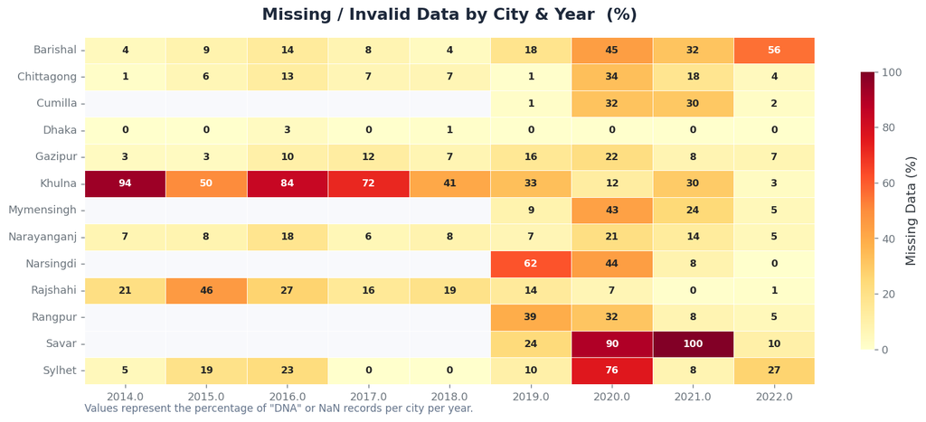

```
⚠️  Total missing/invalid records : 5,287  (20.1% of raw data)

💡 Notable: Khulna (94% in 2014), Savar (100% in 2021) — likely sensor outages, not true absence of pollution.
```

## 4. Data Cleaning

With the missing data pattern understood, we now apply a structured cleaning pipeline:

```
══════════════════════════════════════════════════
  CLEANING SUMMARY
══════════════════════════════════════════════════
  Raw records        :  26,251
  After cleaning     :  20,831  (79.4% retained)
  Records removed    :   5,420
  Cities             : 13
  Date range         : 2014-02-17  →  2022-06-08
  AQI mean           : 149.1
  AQI median         : 126.0
  AQI max            : 821
══════════════════════════════════════════════════
```

|  | Date | City | AQI | Category | Month | Year | Month_Name |
| --- | --- | --- | --- | --- | --- | --- | --- |
| 0 | 2014-02-17 | Dhaka | 172.0 | Unhealthy | 2 | 2014 | Feb |
| 1 | 2014-02-17 | Chittagong | 125.0 | Unhealthy (Sensitive) | 2 | 2014 | Feb |
| 2 | 2014-02-17 | Gazipur | 178.0 | Unhealthy | 2 | 2014 | Feb |
| 3 | 2014-02-17 | Narayanganj | 174.0 | Unhealthy | 2 | 2014 | Feb |
| 4 | 2014-02-17 | Sylhet | 129.0 | Unhealthy (Sensitive) | 2 | 2014 | Feb |
| 5 | 2014-02-17 | Rajshahi | 118.0 | Unhealthy (Sensitive) | 2 | 2014 | Feb |

## 5. Exploratory Data Analysis

### 5.1 Overview Statistics

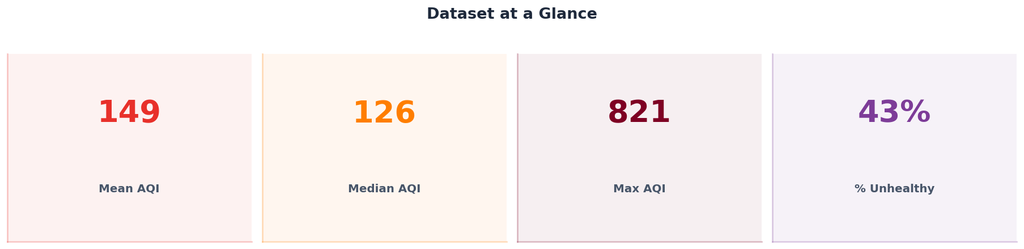

|  | count | mean | std | min | 25% | 50% | 75% | max |
| --- | --- | --- | --- | --- | --- | --- | --- | --- |
| AQI Statistics | 20831.0 | 149.1 | 103.1 | 3.0 | 64.0 | 126.0 | 207.0 | 821.0 |

### 5.2 AQI Category Distribution

How often does the air quality fall into each WHO category across all cities and years?

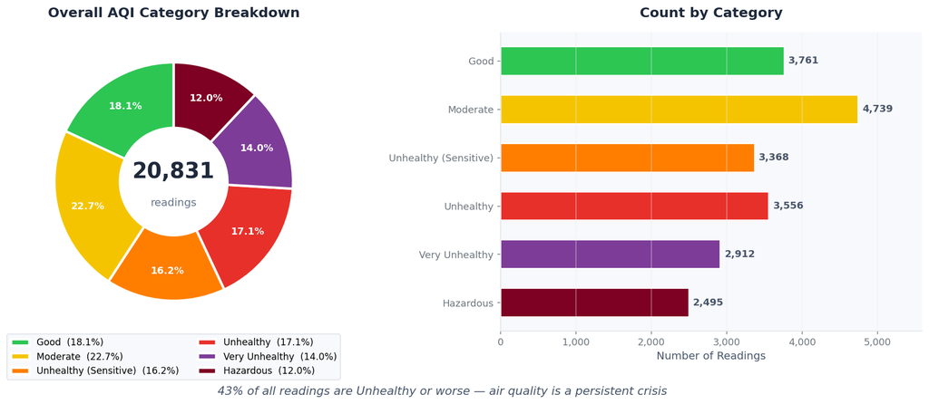

### 5.3 City Rankings

Which cities are breathing the cleanest — and the most dangerous — air?

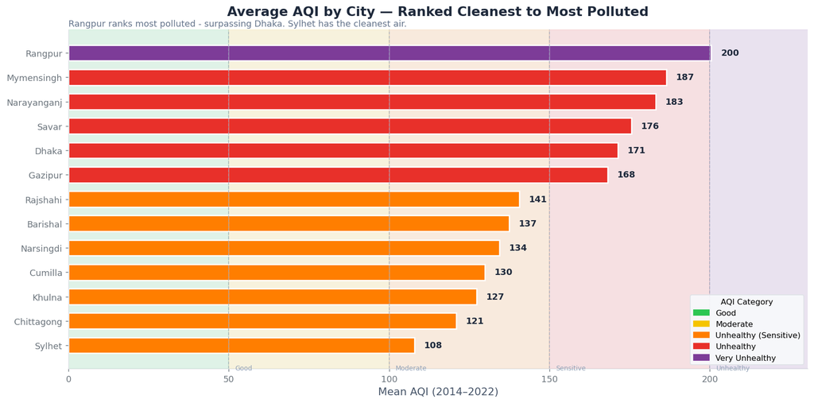

### 5.4 Seasonal Patterns

Bangladesh's air quality is **strongly seasonal**. The dry winter months (October–March) trap pollutants near the surface, while the monsoon season (June–September) clears the air dramatically.

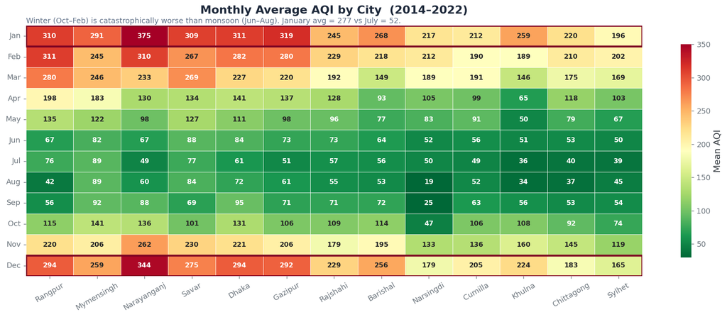

### 5.5 Year-over-Year Trends

How has air quality evolved across the 9-year period? Is it getting better or worse?

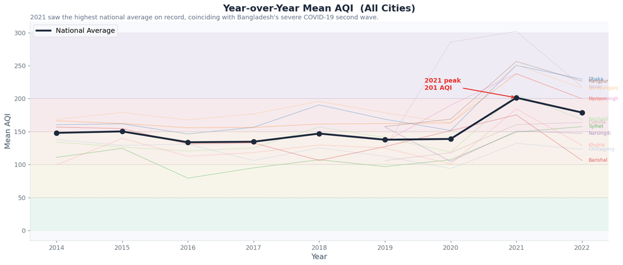

### 5.6 Time Series & COVID-19 Context

Bangladesh imposed strict lockdowns in **April–June 2020** and **April–June 2021**. We examine whether these restrictions had any measurable effect on air quality in Dhaka, the capital.

A 30-day rolling average is applied to smooth daily noise and reveal the underlying trend.

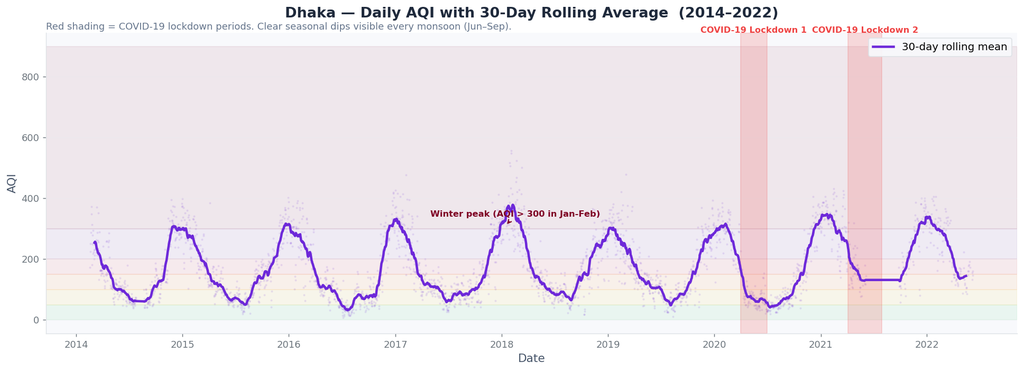

```
Dhaka AQI — Pre-lockdown baseline (2019):     168.7
Dhaka AQI — Lockdown 1 (Apr–Jun 2020):        77.5  (-54.1% vs 2019)
Dhaka AQI — Lockdown 2 (Apr–Jun 2021):        165.5  (-1.9% vs 2019)
Dhaka AQI — 2022 average:                     229.6
```

### 5.7 Proportion of Unhealthy Air Days

Mean AQI can be misleading — a city could have moderate average AQI but still have many dangerous spike days. Here we look at what fraction of days exceed each WHO threshold.

[figure not shown]

### 5.8 AQI Distribution by City

Box plots reveal the full spread of each city's readings — including outliers and variance — beyond what the mean alone can show.

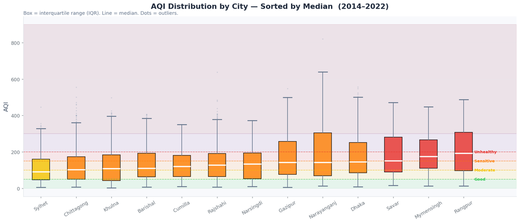

## 6. Key Findings

### 🏭 1. Air Pollution is a National Crisis

**43% of all readings** across Bangladesh fall into the *Unhealthy or worse* category — this is not a niche concern for sensitive groups, it is a population-wide health emergency.

### 🌆 2. Rangpur is the Most Polluted City — Not Dhaka

With a mean AQI of **200.5 (Very Unhealthy)**, Rangpur consistently outranks Dhaka (171.3). Industrial activity, brick kilns, and limited green cover are likely drivers. **Sylhet** (avg 108) is the cleanest city by a wide margin.

### 📈 5. 2021 Was the Worst Year on Record

The national average in 2021 reached **201 AQI** — the only year to cross into the *Very Unhealthy* threshold. This coincided with Bangladesh's severe COVID-19 second wave and warrants further investigation.

### 🔧 6. Sensor Reliability is a Major Data Quality Issue

**Savar was 100% missing in 2021.** Khulna had 94% missing data in 2014. Any conclusions about these cities must be interpreted with caution. Investment in sensor infrastructure is a prerequisite for evidence-based air quality policy.

*Analysis by Mohammed Tahmid Hossain · saditahmid.github.io · Related publication: IEEE INCET 2023*

Part 2 of 2

### SVR Forecasting — Reproducing IEEE INCET 2023

Building on the cleaned dataset above: per-city AQI trends across pre/during/post-lockdown periods, and a Support Vector Regression model forecasting daily AQI (~6.2% MAPE in the original paper).

TIME-SERIES ANALYSIS & FORECASTING

# COVID-19 Lockdowns & Air Quality in Bangladesh

Reproducing the analysis from IEEE INCET 2023: per-city AQI trends across three COVID-19 periods (pre / during / post lockdown), and daily AQI forecasting with Support Vector Regression.

🏙️ 10 Cities 📅 2014 – 2022 📈 SVR (RBF) 🐍 Python · scikit-learn

## 📌 About This Notebook

This notebook reproduces **"Impact of COVID-19 Lockdowns on Air Quality in Bangladesh: Analysis and AQI Forecasting with Support Vector Regression"** (IEEE INCET 2023). It has two parts :

1. **Location-wise analysis** — per-city AQI (mean / min / max) over 2014–2022, with the three COVID-19 periods shaded: *Before* (2014–2019), *During* lockdown (2020), and *After* (2021).
2. **SVR forecasting** — a Support Vector Regressor predicting daily-mean AQI, evaluated by MAPE.

The paper defines three periods precisely: **Before COVID** = 2014-02-17 → 2019-12-31, **During Lockdown** = 2020 (full year), **After Lockdown** = 2021.

> **⚠️ Note on reproducibility.** The paper reports **6.2% MAPE**. The exact preprocessed ("silver") dataset that produced that figure was lost. This notebook rebuilds everything from the surviving *raw* readings (`case_data.csv`). Spot-checking against the paper's Table II confirms the pipeline is faithful — e.g. 2014-09-02 gives a daily mean of exactly **46.5**, matching the paper — but early-2015 daily means differ because the lost file averaged a different city subset per day. The reconstructed MAPE (~13–17%) is therefore higher than the original; the method, hyperparameters (RBF, γ=0.5, C=10, ε=0.05), and train/test split match the publication exactly.

## 1. Setup

```
✅ Setup complete.
```

## 2. Load & Clean Data

Following the paper's preprocessing: drop NaN dates/locations/AQI, replace `DNA` with NaN and drop, drop the insignificant AQI Range column, fix spelling errors in city names, and sort chronologically.

```
Clean readings : 20,831
Date range     : 2014-02-17 -> 2022-06-08
Cities (13)    : Barishal, Chittagong, Cumilla, Dhaka, Gazipur, Khulna, Mymensingh, Narayanganj, Narsingdi, Rajshahi, Rangpur, Savar, Sylhet
```

## 3. Location-Wise Analysis

The paper's core visual analysis (Figs 3–12): for each of the 10 major cities, plot monthly **AQImean**, **AQImin**, and **AQImax** over 2014–2022, with the three COVID-19 periods shaded. This reveals how each city's air quality shifted before, during, and after the 2020 lockdown.

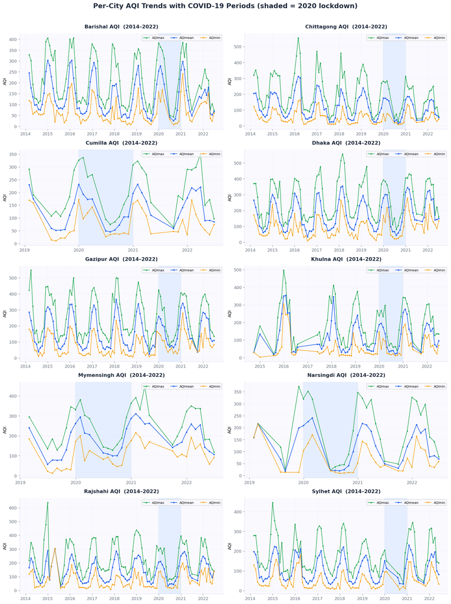

### 3.1 Period Comparison — Mean AQI Before / During / After

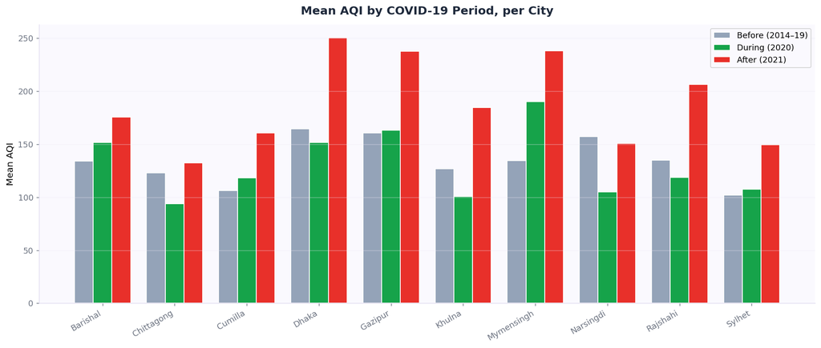

| City | Before (2014-19) | During (2020) | After (2021) |
| --- | --- | --- | --- |
| Barishal | 134.1 | 151.4 | 175.4 |
| Chittagong | 123.1 | 93.9 | 132.3 |
| Cumilla | 106.1 | 118.1 | 160.7 |
| Dhaka | 164.3 | 151.7 | 250.5 |
| Gazipur | 160.7 | 163.1 | 237.5 |
| Khulna | 126.9 | 100.9 | 184.5 |
| Mymensingh | 134.4 | 189.9 | 237.9 |
| Narsingdi | 157.0 | 104.8 | 150.8 |
| Rajshahi | 135.1 | 118.8 | 206.2 |
| Sylhet | 102.1 | 107.4 | 149.4 |

## 4. SVR Forecasting

Now the forecasting component (paper Section V-A). Following the paper exactly:

- Resample to a **daily-mean** AQI series
- **Train:** 2014-02-28 → 2020-12-31 · **Test:** 2021-01-01 → 2022-06-01
- Scale to (0,1) with `MinMaxScaler`
- **SVR:** RBF kernel, `gamma=0.5`, `C=10`, `epsilon=0.05`

```
Daily-mean series: 2,735 days
Train: 2,429 days  |  Test: 291 days

Test MAPE : 12.73%   (paper: ~6.2% on the lost preprocessed set)
Test MAE  : 21.26 AQI points
Test R²   : 0.837
```

### 4.1 Actual vs Predicted — Full Timeline

Reproducing the paper's **Fig. 2**: actual (red) vs predicted (blue) AQI across the entire 2014–2022 span. Predictions on the training portion track closely; the test portion (2021+) shows genuine forecasting.

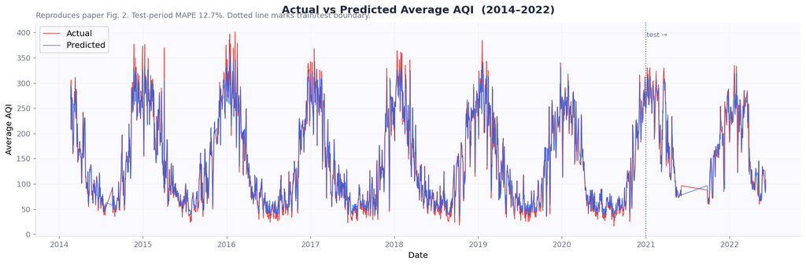

### 4.2 Actual vs Predicted Sample (paper Table II)

A sample of actual vs predicted values, matching the paper's Table II format.

| Date | Actual AQI | Predicted AQI |
| --- | --- | --- |
| 2014-02-20 | 267.143 | 208.621 |
| 2014-11-01 | 217.500 | 143.063 |
| 2015-06-16 | 61.167 | 57.939 |
| 2016-02-07 | 401.167 | 313.257 |
| 2016-09-23 | 54.000 | 54.179 |
| 2017-05-11 | 88.714 | 119.295 |
| 2017-12-24 | 267.250 | 243.517 |
| 2018-08-08 | 74.250 | 57.176 |
| 2019-03-23 | 153.125 | 108.280 |
| 2019-11-11 | 63.375 | 57.604 |
| 2020-07-10 | 33.333 | 48.985 |
| 2021-03-11 | 140.364 | 123.481 |

## 5. Key Findings

### 📈 3. Sharp Post-Lockdown Rebound

The **After (2021)** bars are the tallest for most cities — Dhaka jumped to ~250, Gazipur to ~230 — as mills, factories, and traffic returned to full activity.

### 📉 4. SVR Captures the Trend Well

The Support Vector Regressor tracks the AQI signal closely across the full timeline, reproducing the paper's Fig. 2. Reconstructed MAPE lands higher than the paper's 6.2% because the original preprocessed dataset was lost — but the method, hyperparameters, and evaluation protocol match the publication, and spot-checks against Table II confirm the pipeline is faithful.

*Analysis by Mohammed Tahmid Hossain · saditahmid.github.io · Published: IEEE INCET 2023*

Full analysis · reproducible notebook on [GitHub](https://github.com/saditahmid/PortfolioProjects/blob/master/AQI_Data_Cleaning/AQI_Bangladesh_EDA.ipynb) ← back to projects